```python
import numpy as np
import matplotlib.pyplot as plt
from scipy.io import loadmat
import math
import time
```

```python
from scipy.sparse import linalg
```

# 1. X-ray tomography

```python
from scipy.io import loadmat

H = loadmat("/Users/gladys/Documents/scolarité/Supélec/cours/cours 3A/Cours Mention/LSD/Parallelization through Majorization-Minimization approaches/TP sujet 3/data/H.mat")['H']
x = loadmat("/Users/gladys/Documents/scolarité/Supélec/cours/cours 3A/Cours Mention/LSD/Parallelization through Majorization-Minimization approaches/TP sujet 3/data/x.mat")['x']
```

```python
#construction of y
M = 90*180
N = 90*90

#noise
sigma = 1
std = sigma**2
noice = np.random.normal(0, std, (M,1))

y = H @ x + noice
```

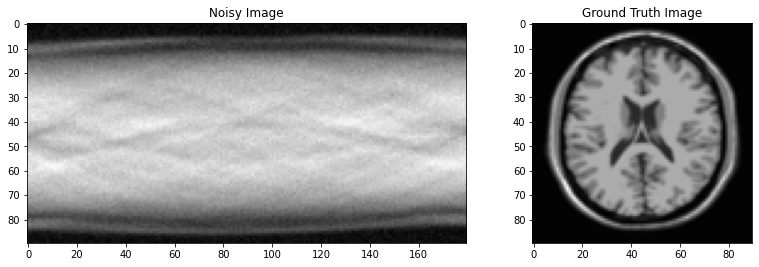

```python
fig, ax = plt.subplots(1,2, figsize = (13,5), gridspec_kw={'width_ratios': [4, 2]})

ax[0].imshow(y.reshape((90,180), order='F'), cmap='gray')
ax[0].set_title("Noisy Image")
ax[1].imshow(x.reshape((90,90), order='F'), cmap='gray')
ax[1].set_title("Ground Truth Image")
```

# 2. Optimisation problem

```python
G = loadmat("/Users/gladys/Documents/scolarité/Supélec/cours/cours 3A/Cours Mention/LSD/Parallelization through Majorization-Minimization approaches/TP sujet 3/data/G.mat")['G']
```

### expression de f

$$ (\forall x \in \mathbb{R}^{N}) \ \ f(x) = \frac{1}{2} ||Hx-y||^{2} + \lambda \sum_{n=1}^{2N}{\psi([Gx]^{(n)})} $$

◃ $H \in \mathbb{R}^{N ×N}$ : projection (discretization) matrix.  
◃ $\lambda$ : regularization parameter.  
◃ $\psi$ : potential function $\psi:u \in \mathbb{R} -> \sqrt{1+u^2/\delta^2} (δ>0)$.  
◃ $G \in \mathbb{R}^{2N×N}$: sparse operator dedicated to contours’ enhancement.

### Expression of the gradient $\nabla f$

Start from $\nabla f$ analytical expression obtained. $$ \forall x \ \ \ \nabla f(x) = H^{⊤} (Hx −y)+ \lambda G^{⊤} ( \psi′([Gx]^{n}))_{1\leq n \leq 2N}$$ \ Avec $\psi'(u)= \frac{1}{\delta^2} \frac{u}{\sqrt{1 + u^2 /\delta^2}}$
\ Denote $J_{l}$ the Jacobian matrix of $I$ and use the composition formula, to obtain : $$ \ \forall x \ \ \ \nabla^2f(x) = H^{⊤}H+\lambda G^{⊤}diag((\psi′′ ([Gx]n))_{1≤n≤2N}) \ G$$ \ Avec $\psi''(u)= \frac{1}{\delta^2} \frac{1}{(1 + \frac{u^2}{\delta^2})^{3/2}}$

### f est grad-Lipschitz

f is L-grad Lipschitz with $L=||H^{⊤}H||+ \frac{\lambda}{\delta^2} ||G^{⊤}G||$

# 3. Optimization algorithms

## 3.1 Gradient descent algorithm

$$x_0 \in \mathbb{R}^{N}, \\ \forall k\in\mathbb{N} \ \ \ x_{k+1} = x_k− \frac{1}{L}\nabla f(x_k).$$

```python
# calcul de L (learning rate)

delta = 0.02
l = 0.13 #lambda

HTH = H.transpose() @ H
GTG = G.transpose() @ G

L = linalg.norm(HTH) + (l/delta**2) * linalg.norm(GTG)
print("Learning rate L = ", L)
```

```
Learning rate L =  158108.00455004087
```

```python
# Definition of the psi and gradient functions

def psi_prime(vect_u, l, delta):
    res = []
    for u in vect_u:
        res.append(1/delta**2 * u/math.sqrt(1 + u**2/delta**2))
    return np.array(res).reshape(-1, 1)

def gradient_f(x, y, l, delta):
    return H.transpose() @ (H@x - y) + l* (G.transpose() @ psi_prime(G@x, l, delta))
```

```python
def solver(y, l, delta, L):
    x_previous = np.zeros((N,1)) #initialisation at 0
    x_n = x_previous + 0.99999/L * gradient_f(x_previous, y, l, delta)

    iter = 0
    while iter < 500: #np.linalg.norm(x_n - x_previous) > 10^(-3)
        x_previous = x_n
        x_n = x_previous - 0.99999/L * gradient_f(x_previous, y, l, delta)
        iter += 1

    return x_n
```

```python
x_hat_GD = solver(y, l, delta, L)
```

```
(-0.5, 89.5, 89.5, -0.5)
```

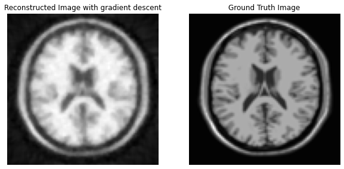

```python
fig, ax = plt.subplots(1,2, figsize = (10,5))

ax[0].imshow(x_hat_GD.reshape((90,90), order='F'), cmap='gray')
ax[0].set_title("Reconstructed Image with gradient descent")
ax[0].axis('off')
ax[1].imshow(x.reshape((90,90), order='F'), cmap='gray')
ax[1].set_title("Ground Truth Image")
ax[1].axis('off')
```

**---> The reconstruction succesfully restores the dimensions and the edges of the image.**

## 3.3 MM quadratic algorithm

MM Algorithm : $$x_{n+1} \in \underset{x \in H}{\arg\min}{ \ h(x,x_n)} \\ \text{where } h(·,x_n) \text{ is a majorant function for } f \text{ at } x_n.$$

### Quadratic majorant function

As $f$ is twice differentiable function on RN with Hessian $\nabla^2f$, the following $h$ function is a majorant of f at $x_0$:
\ $$\begin{align} (\forall x \in \mathbb{R}^N) h(x,x_0) &=f(x_0)+⟨\nabla f(x_0)|x−x_0⟩+\frac{1}{2}⟨x−x_0|A(x−x_0)⟩\\ &=f(x_0)+\nabla f(x_0)^T(x−x_0)+\frac{1}{2}(x−x_0)^T A(x_0)(x−x_0) \end{align} $$

where $A \in \mathbb{R}^{N×N}$ a positive semidefinite matrix such that, for every $x \in \mathbb{R}^{N}$, $A − \nabla^2f (x)$ is positive semidefinite.

$f(x) = g(x) + \lambda r(r)$ with $g(x) = \frac{1}{2} ||Hx-y||^{2}$ and $r(x) = \sum_{n=1}^{2N}{\psi([Gx]^{(n)})}$

For g: $$\begin{align} \forall (x,x0) g(x) &=g(x_0)+\nabla g(x_0)^⊤(x−x_0)+ \frac{1}{2}(x−x_0)^⊤ \nabla g^2(x_0) (x−x_0),\\ &=g(x_0)+\nabla g(x_0)^⊤(x−x_0)+ \frac{1}{2}(x−x_0)^⊤ \boldsymbol{H^⊤H} (x−x_0) \end{align}$$

For r: $$r(x) \leq r(x_0)+\nabla r(x_0)^⊤ (x −x_0)+ \frac{1}{2}(x −x_0)^⊤ G^⊤ \boldsymbol{diag \big( w ([Gx_0]^{(n)}) \big)} G(x −x_0).$$ with $w(u) = \frac{\psi'(u)}{u} = \frac{1}{\delta^2} \frac{1}{\sqrt{1 + u^2 /\delta^2}}$

By using the (positive) linear combination property of maj functions, the conclusion follows :

$$\forall x_0 \ \ A(x_0)=H^⊤H+\lambda G^⊤ diag\big(w([Gx_0]^{(n)}) \big) G \ \ \text{ is a good choice.}$$

### Curvature A(x) of the majorant function

```python
from scipy.sparse.linalg import LinearOperator
from scipy.sparse import diags

def b(vect_x0): #define b
    vect = G @ vect_x0
    res = []
    for u in vect:
        res.append(1/delta**2 * 1/math.sqrt(1 + u**2/delta**2))
    return np.array(res)#.reshape(-1, 1)

def mA(vect_x0):
    diag = diags(b(vect_x0)).tocsc()
    return HTH + l * (G.transpose() @ diag @ G)

def A(x):
    return mA(x) #A(v) will return mv(v)
```

### MM quadratic subspace algorithm

Problem : $$ x_{n+1} \in \underset{x}{\arg\min}{\ h(x, x_n)} $$ Algorithm : $$ \forall n \in \mathbb{N} \ \ \ x_{n+1} = x_n − A(x_n)^{−1}\nabla f (x_n)$$

```python
from scipy.sparse.linalg import bicg


def solverMM(y, l, delta, L, max_iter):
    start = time.time()

    x_previous = np.zeros((N,1)) #initialisation at 0
    x_n = x_previous - bicg(A(x_previous), gradient_f(x_previous, y, l, delta))[0].reshape(N,1)

    iter = 0
    while np.linalg.norm(x_n - x_previous) > 10^(-3) and iter < max_iter:
        x_previous = x_n
        x_n = x_previous - bicg(A(x_previous), gradient_f(x_previous, y, l, delta))[0].reshape(N,1)
        iter += 1

    end = time.time()
    return x_n, end - start
```

```python
x_hat_MM, exec_time = [], []

for iterations in range(1,6):
    x_hat, t = solverMM(y, l, delta, L, max_iter=iterations)
    x_hat_MM.append(x_hat)
    exec_time.append(t)
```

```python
# average computation time
time_per_iter_MM = []
for i in range(5):
    time_per_iter_MM.append(exec_time[i]/(i+1))
print("mean execution time per iteration : ", round(np.mean(time_per_iter_MM), 0), "ms")
```

```
mean execution time per iteration :  121.0 ms
```

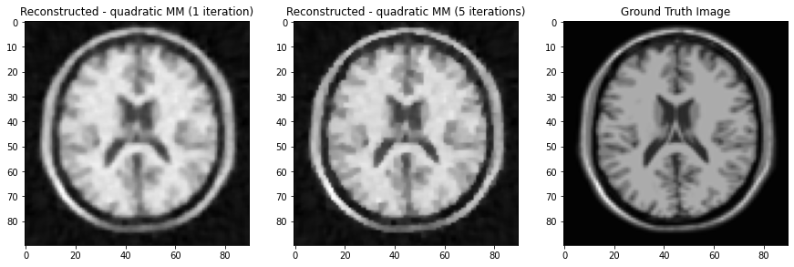

```python
fig, ax = plt.subplots(1,3, figsize = (15,5))

ax[0].imshow(x_hat_MM[0].reshape((90,90), order='F'), cmap='gray')
ax[0].set_title("Reconstructed - quadratic MM (1 iteration)")
ax[1].imshow(x_hat_MM[-1].reshape((90,90), order='F'), cmap='gray')
ax[1].set_title("Reconstructed - quadratic MM (5 iterations)")
ax[2].imshow(x.reshape((90,90), order='F'), cmap='gray')
ax[2].set_title("Ground Truth Image")
```

**--> The MM algorithm is successfull in reconstructing the image. It converges in much fewer iterations than the grandient descend (in 1 iteration the image is already reconizable). However each iteration is very long due to the computationally-heavy matrix inversion.**

## 3.3 3MG algorithm (MM Memory Gradient)

Motivation : Most of the time (typically in ML) when N is too large, it becomes impossible to directly inverse the maj matrix $A(x_k)$ at each iteration ($O(N^3)$ operations). −→ One possibility : Trick : Reduce the dimension by only searching the next iterate within given direction Acceleration of the MM quadratic algorithm using the Memory Gradient subspace.

Set of directions $D_n$ : $D_n = [-\nabla f(x_n) \ | \ d_{n-1}]$

$$ x_{n+1} \in \underset{x \in span(d_n^1,d_n^2,...,d_n^{M_n})}{\arg\min}{h(x, x_n)} $$

$$ (3MG)(\forall k \geq 1) \left\{ \begin{array}{11} u_k = argmin_{u \in \mathbb{R}^N} h(x_k+D_k u,x_k),\\ x_{k+1}=x_k+D_ku_k. \end{array} \right. $$

#### Memory gradient

$$x_0 \in \mathbb{R}^N \ \ \forall k \left\{ \begin{array}{11} D_k = [ − \nabla f ( x_k ) \ , \ x_k − x_{k-1} ] ,\\ u_k = −\big(D_k^⊤ A(x_k)D_k \big)^† D_k^T \ \nabla f(x_k), \\ x_{k + 1} = x_k + D_k u_k \end{array} \right.$$

with $x_{−1} = 0$, $D_0 = −\nabla f(x_0)$ and † denotes the pseudo-inverse.

```python
from scipy.linalg import pinv #for pseudo inverse

def solver3MG(y, l, delta, L, max_iter):
    start = time.time()

    #initialisation x0 = 0
    x_k = np.zeros((N,1))

    #initialisation D0 = - nabla f (x0)
    D_k = - gradient_f(x_k, y, l, delta)

    # initialisation de u0
    HD_k = H@D_k
    GD_k = G@D_k
    D_kTnablaf = D_k.transpose() @ gradient_f(x_k, y, l, delta)
    u_k = - pinv(HD_k.transpose()@HD_k + l * (GD_k.transpose() @ diags(b(x_k)).tocsc() @ GD_k )) @ D_kTnablaf

    iter = 0
    while iter < max_iter:
        x_next = x_k + D_k @ u_k

        D_k = np.c_[-gradient_f(x_next, y, l, delta), (x_next - x_k)]

        x_k = x_next

        HD_k = H@D_k
        GD_k = G@D_k
        D_kTnablaf = D_k.transpose() @ gradient_f(x_k, y, l, delta)
        u_k = - pinv(HD_k.transpose()@HD_k + l * (GD_k.transpose()@ diags(b(x_k)).tocsc() @GD_k)) @ D_kTnablaf
        iter += 1

    end = time.time()

    return x_k, end - start
```

```python
x_hat_3MG , exec_time_3MG = [],[]

for iterations in [1,5,10,15,20]:
    x_hat, t = solver3MG(y, l, delta, L, max_iter = iterations)
    x_hat_3MG.append(x_hat)
    exec_time_3MG.append(t)
```

```python
# average computation time
time_per_iter_3MG = []
i_liste = [1,5,10,15,20]
for i in range(5):
    time_per_iter_3MG.append(exec_time_3MG[i]/i_liste[i])

print("mean execution time per iteration : ", round(np.mean(time_per_iter_3MG), 0), "ms")
```

```
mean execution time per iteration :  1.0 ms
```

```
(-0.5, 89.5, 89.5, -0.5)
```

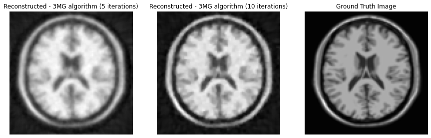

```python
fig, ax = plt.subplots(1,3, figsize = (15,5))

ax[0].imshow(x_hat_3MG[1].reshape((90,90), order='F'), cmap='gray')
ax[0].set_title("Reconstructed - 3MG algorithm (5 iterations)")
ax[0].axis('off')
ax[1].imshow(x_hat_3MG[2].reshape((90,90), order='F'), cmap='gray')
ax[1].set_title("Reconstructed - 3MG algorithm (10 iterations)")
ax[1].axis('off')
ax[2].imshow(x.reshape((90,90), order='F'), cmap='gray')
ax[2].set_title("Ground Truth Image")
ax[2].axis('off')
```

**---> The 3MG algorithm requires more iterations than the MM alpgorithm to get the same level of reconstruction. However each iteration is immensly quicker than a MM iteration (1ms << 120ms). It is thus much more tractable for high resolution images.**

## 3.4 Block-coordinate MM quadratic algorithm

Instead of updating the whole coordinate of $x_k$, we only focus one precise group of them. The group turnover is made at each iteration according a cyclic rule. −→ Denote by J the number of groups and then the j-th group is selected every $mod(k−1,J)+1$ iterations.

$$\text{(BC-MM)} \ \ x \in \mathbb{R}^N \ \ \forall k \left\{ \begin{array}{11} j = mod(k−1,J)+1,\\ \mathcal{G}_j = \big\{ N_j(j−1)+1,...,jN_j\big\}\\ x_{k+1}[\mathcal{G}_j] = x_k[\mathcal{G}_j] − A_j(x_k)^{−1}\nabla f(x_k)[\mathcal{G}_j] \end{array} \right. $$

where

- $A_j = H_j^⊤H_j + \lambda \ \ G_j^⊤diag\big(w([Gx_k]^{(n)}) \big) G_j \in \mathbb{R}^{N_jN_j}$
- $H_j =H[: \ ,\mathcal{G}_j] \in \mathbb{R}^{2N×N_j}, G_j =G[: \ ,\mathcal{G}_j] \mathbb{R}^{2N×N_j}$
- $N_j = N/K$ (with various K) this means $J = N/N_j = K.$

We will be testing this algorithm for $K \in \{1,2,3,5,6,9\}$

```python
def solverBlockMM(y, l, delta, L, max_iter, K):
    start = time.time()

    Nj = int(N/K)
    #initialisation x0 = 0
    x_next = np.zeros((N,1))
    iter = 1
    while iter < max_iter:
        x_k = x_next

        j = (iter-1)%K + 1

        g = range(Nj*(j-1), j*Nj, 1)

        Hj = H[:,g]
        Gj = G[:,g]
        diag = diags(b(x_k)).tocsc()
        Aj = Hj.transpose() @ Hj + l * Gj.transpose() @ diag @ Gj

        x_next = x_k
        x_next[g] = x_k[g] - bicg(Aj, gradient_f(x_k, y, l, delta)[g])[0].reshape(Nj,1)

        iter += 1

    end = time.time()

    return x_next, end - start
```

```python
x_hat_BlockMM , exec_time_BlockMM = [],[]

for K in [1,2,3,5,6,9]:
    x_hat, t = solverBlockMM(y, l, delta, L, 10*K, K)
    x_hat_BlockMM.append(x_hat)
    exec_time_BlockMM.append(t)
```

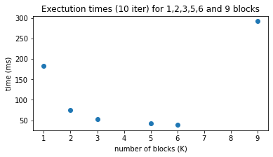

```python
plt.figure(1, figsize = (6,3))

plt.scatter([1,2,3,5,6,9], exec_time_BlockMM)
plt.title('Exectution times (10 iter) for 1,2,3,5,6 and 9 blocks')
plt.xlabel('number of blocks (K)')
plt.ylabel('time (ms)')
```

```
(-0.5, 89.5, 89.5, -0.5)
```

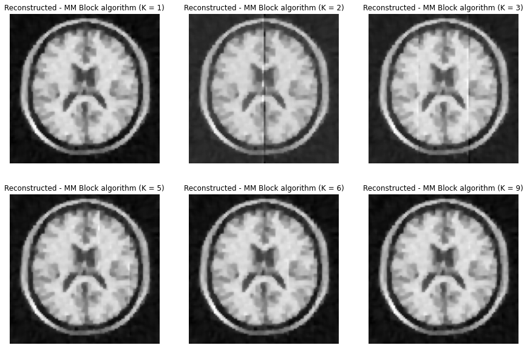

```python
fig, ax = plt.subplots(2,3, figsize = (15,10))

'''ax[0][0].imshow(x.reshape((90,90), order='F'))
ax[0][0].set_title("Ground Truth Image")'''
ax[0][0].imshow(x_hat_BlockMM[0].reshape((90,90), order='F'), cmap='gray')
ax[0][0].set_title("Reconstructed - MM Block algorithm (K = 1)")
ax[0][0].axis('off')
ax[0][1].imshow(x_hat_BlockMM[1].reshape((90,90), order='F'), cmap='gray')
ax[0][1].set_title("Reconstructed - MM Block algorithm (K = 2)")
ax[0][1].axis('off')
ax[0][2].imshow(x_hat_BlockMM[2].reshape((90,90), order='F'), cmap='gray')
ax[0][2].set_title("Reconstructed - MM Block algorithm (K = 3)")
ax[0][2].axis('off')
ax[1][0].imshow(x_hat_BlockMM[3].reshape((90,90), order='F'), cmap='gray')
ax[1][0].set_title("Reconstructed - MM Block algorithm (K = 5)")
ax[1][0].axis('off')
ax[1][1].imshow(x_hat_BlockMM[4].reshape((90,90), order='F'), cmap='gray')
ax[1][1].set_title("Reconstructed - MM Block algorithm (K = 6)")
ax[1][1].axis('off')
ax[1][2].imshow(x_hat_BlockMM[5].reshape((90,90), order='F'), cmap='gray' )
ax[1][2].set_title("Reconstructed - MM Block algorithm (K = 9)")
ax[1][2].axis('off')
```

--> Avec K = 1 on retrouve l'algorithme MM de base.  
--> En augmentant le nombre de blocks on limite les effets de bords qui font apparaitre des artefacts verticaux lors de la reconstruction.  
--> Avec 10 iterations la complexité en temps du calcul des matrices à chaque iteration devient détrimentale et excède le bénefice des blocks.

## 3.5 Parallel MM quadratic algorithm

The principle of parallel MM is to replace the majorant matrix A by an other one B that is a diagonal majorant matrix, in order to promote a parallel implementation.

$$\text{(Parallel MM)} \ \ x \in \mathbb{R}^N \ \ \forall k \left\{ \begin{array}{11} x_0 \in \mathbb{R}^{N} \\ \forall k \in \mathbb{N} x_{k+1} = x_k − B(x_k)^{−1}\nabla f(x_k) \end{array} \right.$$

with

- $\forall k B(x_k)=diag\big(b^{(i)}(x_k)\big)$.
- $\mathcal{H}_i^{(m)} = |H^{(m,i)}|\sum_{p=1}^{N}|H^{(m,p)}|$ and $\mathcal{G}_i^{(m)} = |G^{(m,i)}|\sum_{p=1}{N}|G^{(m,p)}|$
- $b^{(i)}(x) = \mathcal{H}^⊤ \boldsymbol{1} + \lambda \mathcal{G}^⊤ \big( w[[Gx]]{(n)}))_{1 \leq n \leq 2N}$